# 20210620

Takala

包丁を研ぐのが趣味である． 今日は，その包丁を研ぐための砥石のメンテナンスを行った．

砥石は，使っていくとだんだんと真ん中の方が凹んでいく． これをそのまま使い続けると，包丁の刃がちゃんと砥石に当たらず， 研ぎムラができてしまう．

そのため，定期的に以下の面直し砥石なるものを使い，砥石自体を整形する必要がある． 今日やったのは，この作業だ．

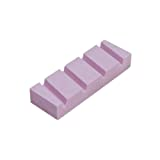

- [セラミック 面直し砥石 水平君 小(155×55) ブランド: 今西製砥(Imanishi)](https://amzn.to/3iT8jxA)

まず，凹んだ砥石に鉛筆で格子を書き込む． これにより面直し砥石で平らにしていく課程で， どこがまだ凹んだままなのか一目瞭然となる．

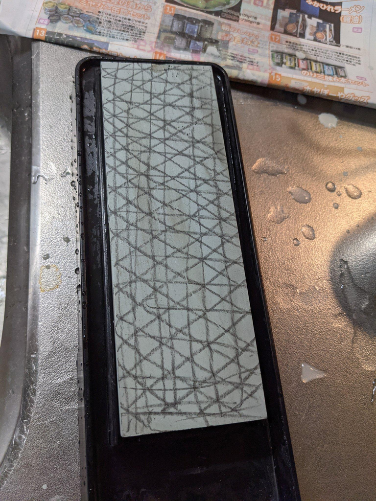

第1段階

面直し砥石で水平になるように削っていく．

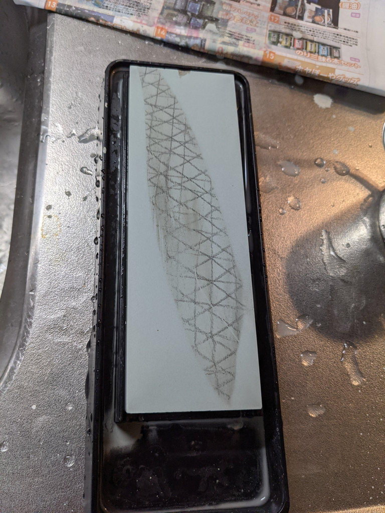

第2段階

やはり真ん中の方が凹んでいる．

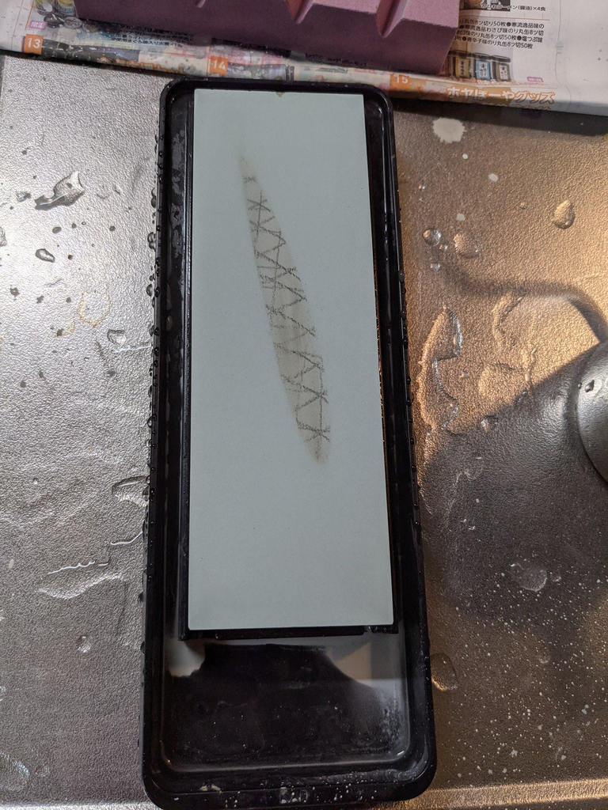

第3段階

15分くらいひたすら削っていきやっと鉛筆の格子が綺麗に消えた． 上部の欠けもちゃんとなくなっている．

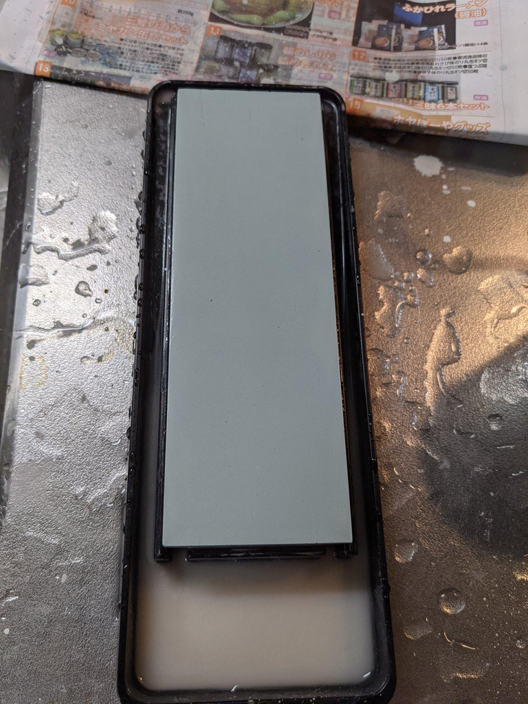

第4段階

面全体を凹んでた部分と同じレベルまで削りとっていることになるので， なかなか大変な作業であることが分かるだろう．

この生まれ変わった砥石を使って，切れ味の良い包丁を生産していきたい．